# homework 1

Joanna Gajewska

7 March 2019

## Wstęp

Zadanie jakie należało wykonać polegało na przeprowadzeniu eksploracji danych jake otrzymano z API Allegro, zebranych w ciągu jednego dnia. W raporcie przedstawiono korelacje między cechami jakimi operowano.

# Wstępne przedstawienie danych

Nazwy zmiennych:

```
##  [1] "main_category"          "lp"
##  [3] "date"                   "item_id"
##  [5] "categories"             "pay_option_on_delivery"
##  [7] "pay_option_transfer"    "seller"
##  [9] "price"                  "it_is_allegro_standard"
## [11] "it_quantity"            "it_is_brand_zone"
## [13] "it_seller_rating"       "it_location"
## [15] "main_category_eng"
```

# Ogólne przedstawienie danych ilościowych

Cena:

```
##      Min.   1st Qu.    Median      Mean   3rd Qu.      Max.
##      0.00      9.00     24.99     76.81     68.45 119000.00
```

Ilość sprzedanych produktów:

```
##    Min. 1st Qu.  Median    Mean 3rd Qu.    Max.
##       0       6      95    6748     931   99999
```

Popularność sprzedawców:

```
##    Min. 1st Qu.  Median    Mean 3rd Qu.    Max.
##      -1    1581    6711   20403   21007  292074
```

# Poprawność danych

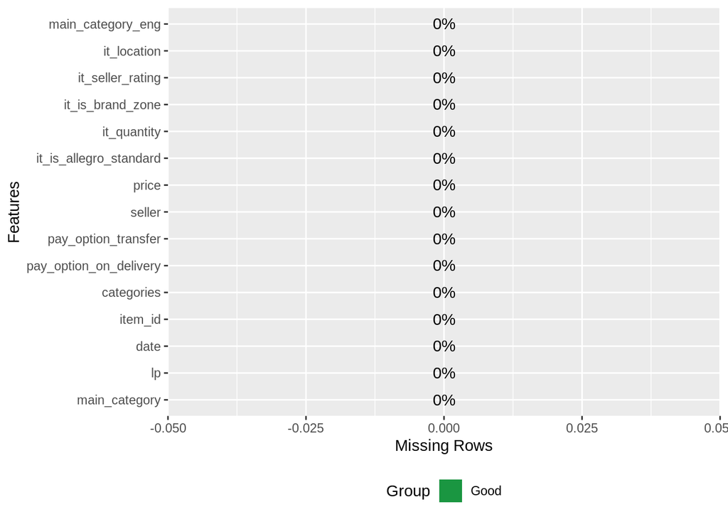

Z powyższego wykresu widać, że dane są kompletne.

# Korelacje cech

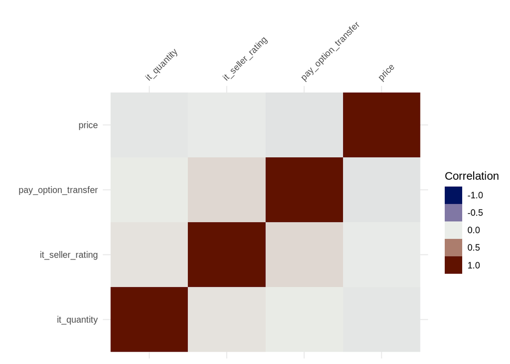

Na wykresie można zauważyć znikomą zależność między ilością ocen jakie otrzymał sprzedawca od możliwości płacenia przez transfer. Sprzedawcy umożliwiający płatność online cieszą się większą popularnością.

# Badanie zależności ilości sprzedanych produktów od ich cen

W pierwszym kroku wykonano podział w kontekście cen. W przedziale 0-100 zł zawiera się ponad 75 % sprzedanych produktów.

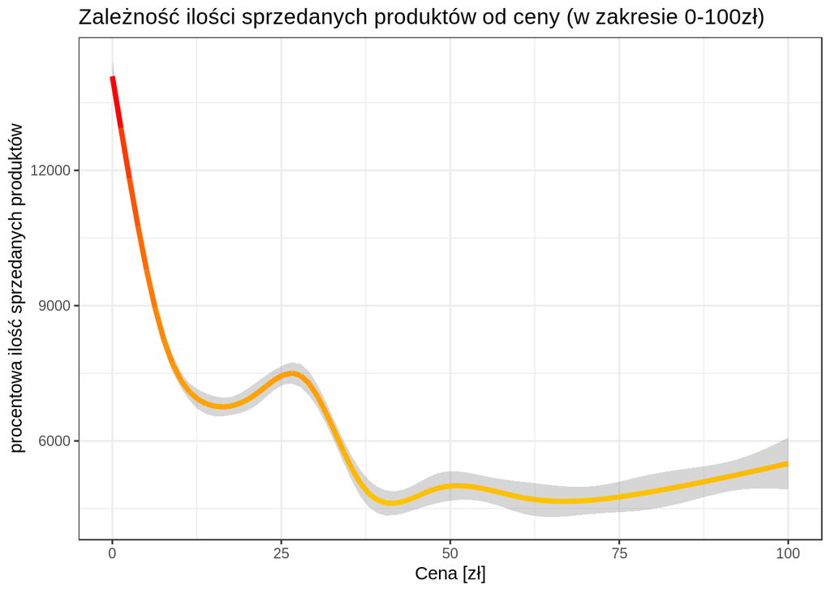

Poniżej przedstawiono wykres z zakresu cenowego 100-500 zł, gdyż jest to przedział w którym się mieści nieco ponad 75 % pozostałych sprzedanych produktów.

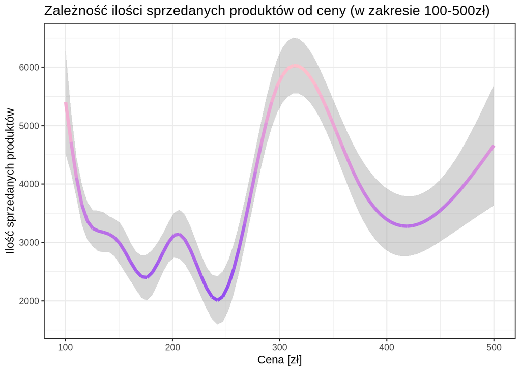

Analizując powyższe wykresy, można zauważyć, iż dużą popularnością cieszą się szczegównie produkty w cenach poniżej 100 zł, zwłaszcza w przedziale od najniższych cen do ~40 zł.

Dla drugiego zakresu (100-500zł) ewidentnie widać skok dla wartości produktów wynoszącej 300 zł.

# Badanie zależności ilości sprzedanych produktów od ich kategorii z uwzględnieniem czy dany produkt jest w standardzie allegro.

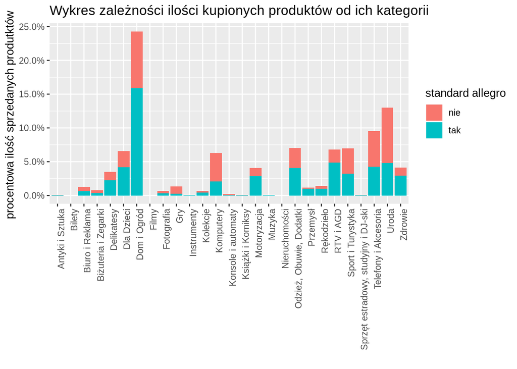

Jak widać z powyższego wykresu największą popularnością cieszy się kategoria Dom i Ogród, kolejno Uroda, Telefony i Akcesoria. Ilość sprzedanych produktów jest umiarkowanie podzielona względem tego czy zwierają się w standardzie allegro czy nie.

# Badanie zależności ilości sprzedanych produktów od popularności sprzedawców z uwzględnieniem opcji płatności

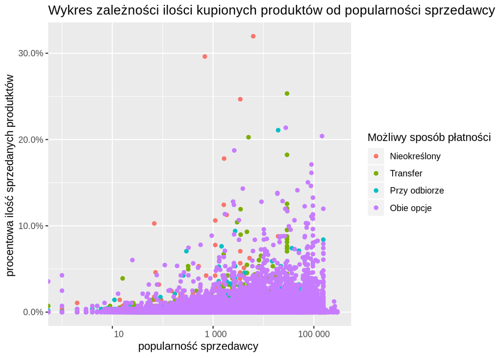

Jak widać z powyższego wykresu, najwięcej produktów (w nie wielkich ilościach) było kupowanych z możliwością obu opcji płątności, rzadkością są produkty które mają jedynie jedną możliwość zapłaty. Istnieją również takie, dla których sposób płacenia nie został określony. Z wykresu wynika, że takie były kupowane w największych ilościach jednorazowo.

# Badanie zależności ilości kupionych produktów od godziny

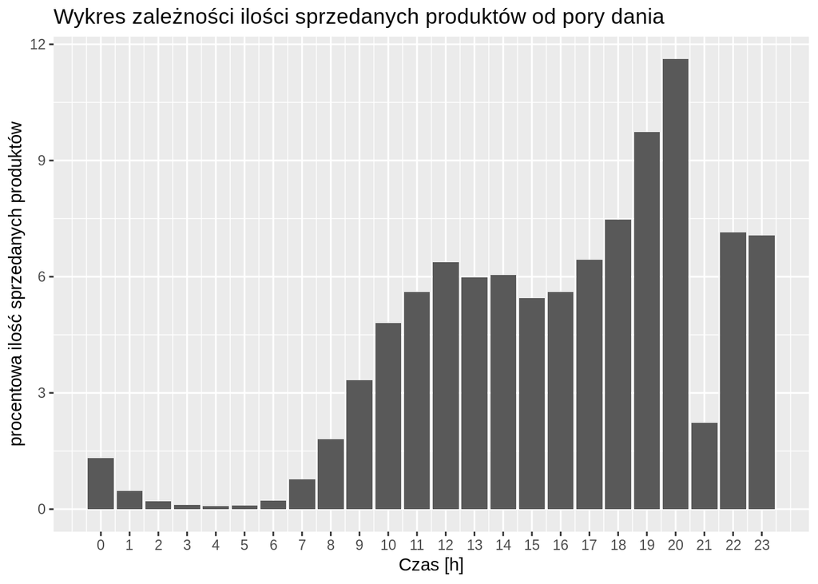

Analizując powyższy wykres widać, że najczęściej klienci robią zakupy w godzinach popołudniowych, a w szczegówności wieczornych. Dla godziny 20 otrzymano najwyższy wynik sprzedanych produktów.